# rail

```python
import pandas as pd
import numpy as np
import matplotlib.pyplot as plt
from sklearn.tree import DecisionTreeClassifier
from sklearn.model_selection import train_test_split

# 假设你已经加载了自己的数据集
data = pd.read_csv("2020-11-15成渝高铁上行成都局1车在前3号弓_All.csv", encoding='utf-8')  # 替换为实际路径
data.columns = data.columns.str.replace(' ', '')
new_columns = [
    "WKm", "Samp", "P1", "P2", "P3", "P4",
    "VAB", "LAB", "Temp", "VA",
    "VA1", "VA2", "VA3", "VA4",
    "S1P", "S2P", "UC", "CC",
    "ACC", "HP", "Imp", "CDV", "CH",
    "NC", "NV", "LA", "LA1",
    "LA2", "LA3", "LA4", "SC",
    "SD", "R1", "R2", "R3", "R4", "Sp", "MM",
    "Sup", "NCH1", "NCH2", "NCDV1",
    "NCDV2", "NCW1", "NCW2", "CWG",
    "Sus", "Pow"
]

# 为 data 设置新的列名
data.columns = new_columns
# 分离特征和目标
X = data.drop(['P1', 'P2', 'P3', 'P4'], axis=1)  # 排除所有目标变量
y = data[['P1', 'P2', 'P3', 'P4']]  # 目标变量是多个列

# 数据预处理
X_train, X_test, y_train, y_test = train_test_split(
    X, y, test_size=0.2, random_state=42
)

# 创建决策树模型
clf = DecisionTreeClassifier()

# 训练模型
clf.fit(X_train, y_train)

# 获取特征重要性
importances = clf.feature_importances_
```

整公里数 -> WKm 采样点 -> Samp

压力1 -> P1, 压力2 -> P2, 压力3 -> P3, 压力4 -> P4

垂加基 -> VAB, 横加基 -> LAB

温度 -> Temp

垂加 -> VA, 垂加1 -> VA1, 垂加2 -> VA2, 垂加3 -> VA3, 垂加4 -> VA4

滑板1压力 -> S1P, 滑板2压力 -> S2P

无补偿接触力 -> UC, 有补偿接触力 -> CC, 空气动力补偿接触力 -> ACC

硬点 -> HP

冲击 -> Imp

接触拉出值 -> CDV, 接触导高 -> CH

网流 -> NC

网压 -> NV

纵加 -> LA, 纵加1 -> LA1, 纵加2 -> LA2, 纵加3 -> LA3, 纵加4 -> LA4

火花次数 -> SC, 火花时间 -> SD

保留1 -> R1, 保留2 -> R2, 保留3 -> R3, 保留4 -> R4

速度 -> Sp

公里标 -> MM

支柱 -> Sup

非接触导高1 -> NCH1, 非接触导高2 -> NCH2

非接触拉出值1 -> NCDV1, 非接触拉出值2 -> NCDV2

非接触磨耗1 -> NCW1, 非接触磨耗2 -> NCW2

接触线坡度 -> CWG

吊悬 -> Sus

功率 -> Pow

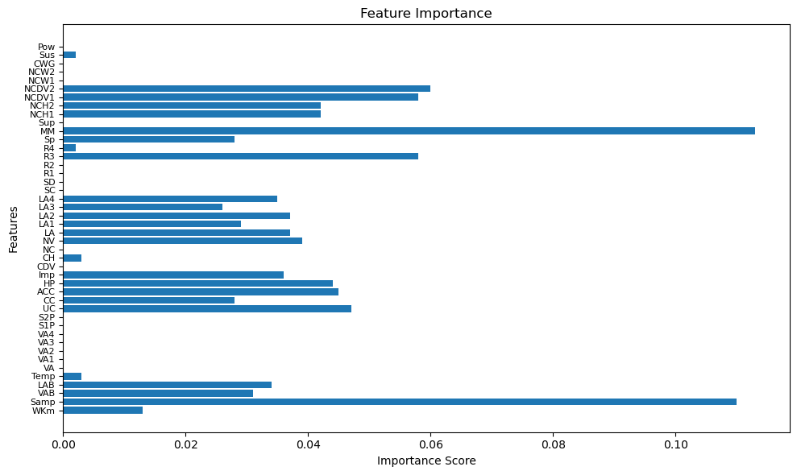

```python
# 绘制特征重要性
plt.figure(figsize=(10, 6))
plt.barh(
    range(len(importances)),
    np.round(importances, 3),
    tick_label=X.columns  # 特征名称来自 DataFrame 列名
)
plt.title("Feature Importance")
plt.xlabel("Importance Score")
plt.ylabel("Features")

# 调整特征名称的字体大小
plt.yticks(fontsize=8)  # 将字体大小调整为 8，你可以根据需要调整大小

plt.tight_layout()
plt.show()
```